# midterm project team 5

2022-12-12

# Research Topic

Our research topic is **Trend of Major Types of Crimes commited by White Males in the DC Area in 2016-2021**. We chose this topic because we are interested in the impact of COVID-19 on crimes. We will use [the data provided by the Metropolitan Police of DC](https://mpdc.dc.gov/node/1379551) regarding adult arrests over a time period stretching between 2016-2021.

# Data Shaping

## Read Data

We read the data .CSV files of adults arrest in DC area from 2016-2021

## Correct Anomalies

### Remove abnormal values

To see whether there were abnormal values, we created the table showing some statistics for numerical variables.

Table: Statistics summary.

|  | Arrest.Year | Arrest.Hour | Age |
| --- | --- | --- | --- |
| Min | Min. :2016 | Min. : 0.00 | Min. : 18.00 |
| Q1 | 1st Qu.:2017 | 1st Qu.: 6.00 | 1st Qu.: 25.00 |
| Median | Median :2018 | Median :12.00 | Median : 32.00 |
| Mean | Mean :2018 | Mean :11.81 | Mean : 35.19 |
| Q3 | 3rd Qu.:2019 | 3rd Qu.:18.00 | 3rd Qu.: 43.00 |
| Max | Max. :2021 | Max. :23.00 | Max. :121.00 |

The maximum age was too old. 55 rows were assigned an age of over 100 years (117-121 ) in these data, and it seemed to be wrong. Therefore, we dropped these rows.

### Some data cleaning.. Dropping, Binding and Renaming of columns as needed.

```
##  [1] "Arrestee_Type"             "Arrest_Year"
##  [3] "Arrest_Date"               "Arrest_Hour"
##  [5] "Age"                       "Defendant_PSA"
##  [7] "Defendant_District"        "Defendant_Race"
##  [9] "Defendant_Ethnicity"       "Defendant_Sex"
## [11] "Arrest_Category"           "Charge_Description"
## [13] "Arrest_Location_District"  "Offense_Location_District"
```

### Missing Values

```
##             Arrestee_Type               Arrest_Year               Arrest_Date
##                         0                         0                         0
##               Arrest_Hour                       Age             Defendant_PSA
##                         0                         0                     29093
##        Defendant_District            Defendant_Race       Defendant_Ethnicity
##                      9337                         0                         0
##             Defendant_Sex           Arrest_Category        Charge_Description
##                         0                        12                        15
##  Arrest_Location_District Offense_Location_District
##                       184                        11
```

##### Our variables of concern in thsi dataset contain rich data.. over 95% of data available in each useful column.. will not delete any rows

```
##  [1] "Arrestee_Type"             "Arrest_Year"
##  [3] "Arrest_Date"               "Month"
##  [5] "Day"                       "Arrest_Hour"
##  [7] "Age"                       "Defendant_PSA"
##  [9] "Defendant_District"        "Defendant_Race"
## [11] "Defendant_Ethnicity"       "Defendant_Sex"
## [13] "Arrest_Category"           "Charge_Description"
## [15] "Arrest_Location_District"  "Offense_Location_District"
```

### Correct inconsistent values

`Arrest_Category` had some different values for 2021 and other years:

- Data in 2021 had “Release Violations/Fugitive (Fug)” and “Release Violations/Fugitive (Warr)” although data in other years have “Release Violations/Fugitive” instead of them.
- Data in 2021 had “Fraud and Financial Crimes (Frau)” although data in other years have “Fraud and Financial Crimes”.

Therefore, we coverted these values in 2021 into the correspond values in other years.

## Remove Unnecessary Rows

Since we were interested in crimes committed by while males, we dropped rows where the value of `Defendant_Race` was not “White”. The structure of the final data is shown in the below table.

Data frame structure

| column_name | class | first_values |
| --- | --- | --- |
| Arrestee_Type | character | Adult Arrest, Adult Arrest, Adult Arrest, Adult Arrest, Adult Arrest, Adult Arrest |
| Arrest_Year | integer | 2016, 2016, 2016, 2016, 2016, 2016 |
| Arrest_Date | double | 2016-01-01, 2016-01-01, 2016-01-01, 2016-01-01, 2016-01-01, 2016-01-01 |
| Month | integer | 01, 01, 01, 01, 01, 01 |
| Day | integer | 1, 1, 1, 1, 1, 1 |
| Arrest_Hour | integer | 0, 0, 1, 1, 13, 2 |
| Age | integer | 39, 27, 27, 26, 48, 25 |
| Defendant_PSA | character | Out of State, Out of State, Out of State, Out of State, 404, Out of State |
| Defendant_District | character | Out of State, Out of State, Out of State, Out of State, 4D, Out of State |
| Defendant_Race | integer | WHITE, WHITE, WHITE, WHITE, WHITE, WHITE |
| Defendant_Ethnicity | character | UNKNOWN, NOT HISPANIC, HISPANIC, NOT HISPANIC, NOT HISPANIC, HISPANIC |
| Defendant_Sex | integer | MALE, MALE, MALE, MALE, MALE, MALE |
| Arrest_Category | character | Simple Assault, Simple Assault, Driving/Boating While Intoxicated, Simple Assault, Simple Assault, Simple Assault |
| Charge_Description | character | Threats To Do Bodily Harm -misd, Simple Assault, Driving While Intoxicated -2nd Off, Simple Assault, Simple Assault, Simple Assault |
| Arrest_Location_District | integer | 2D, 3D, 4D, 5D, 1D, 3D |
| Offense_Location_District | integer | 2D, 3D, 4D, 5D, 1D, 3D |
| Weekday | integer | Friday, Friday, Friday, Friday, Friday, Friday |

# Yuchuan’work Start from here

District: 1D-5D

Weekday: Monday-Sunday

generation: A(18-24),B(25-39), C(40-59), D(60-80), the sample above 80 is not adequate for analysis

```
##        Arrestee_Type Arrest_Year Arrest_Date Month Day Arrest_Hour Age
## 118136  Adult Arrest        2019  2019-12-30    12  30           7  25
## 118162  Adult Arrest        2019  2019-12-31    12  31          11  24
## 118205  Adult Arrest        2019  2019-12-31    12  31           6  32
## 118206  Adult Arrest        2019  2019-12-31    12  31           6  49
## 118213  Adult Arrest        2019  2019-12-31    12  31           7  42
## 118237  Adult Arrest        2019  2019-12-31    12  31           9  42
##        Defendant_PSA Defendant_District Defendant_Race Defendant_Ethnicity
## 118136           405                 4D          WHITE            HISPANIC
## 118162           304                 3D          WHITE        NOT HISPANIC
## 118205           407                 4D          WHITE            HISPANIC
## 118206           305                 3D          WHITE             UNKNOWN
## 118213           506                 5D          WHITE            HISPANIC
## 118237           301                 3D          WHITE             UNKNOWN
##        Defendant_Sex                   Arrest_Category
```

[output cut: 20 more lines]

```
##        Arrestee_Type Arrest_Year Arrest_Date Month Day Arrest_Hour Age
## 118260  Adult Arrest        2020  2020-01-01    01   1           1  37
## 118262  Adult Arrest        2020  2020-01-01    01   1           2  21
## 118268  Adult Arrest        2020  2020-01-01    01   1           2  42
## 118276  Adult Arrest        2020  2020-01-01    01   1           3  29
## 118281  Adult Arrest        2020  2020-01-01    01   1           3  42
## 118302  Adult Arrest        2020  2020-01-01    01   1           8  24
##        Defendant_PSA Defendant_District Defendant_Race Defendant_Ethnicity
## 118260          <NA>                             WHITE        NOT HISPANIC
## 118262          <NA>                             WHITE        NOT HISPANIC
## 118268           404                 4D          WHITE            HISPANIC
## 118276          <NA>                             WHITE             UNKNOWN
## 118281          <NA>                             WHITE             UNKNOWN
## 118302          <NA>                             WHITE            HISPANIC
##        Defendant_Sex Arrest_Category                      Charge_Description
## 118260          MALE    Other Crimes                          Unlawful Entry
## 118262          MALE  Simple Assault                          Simple Assault
## 118268          MALE  Simple Assault                          Simple Assault
## 118276          MALE  Simple Assault                          Simple Assault
## 118281          MALE  Simple Assault                          Simple Assault
## 118302          MALE           Theft Theft Second Degree (all Other Larceny)
##        Arrest_Location_District Offense_Location_District   Weekday
## 118260                       3D                        3D Wednesday
## 118262                       2D                        2D Wednesday
## 118268                       4D                        4D Wednesday
## 118276                       2D                        2D Wednesday
## 118281                       2D                        2D Wednesday
## 118302                       4D                        4D Wednesday
```

Count Pre-Covid Crimes

Build Data Frame for Pre-Covid Crimes

```
##   Dist weekday generation Simple_Assult_counts Traffic_Violations_counts
## 1   1D  Monday          A                    7                         7
## 2   1D  Monday          B                   19                        10
## 3   1D  Monday          C                   12                         3
## 4   1D  Monday          D                   NA                         2
## 5   1D Tuesday          A                   NA                         4
## 6   1D Tuesday          B                   12                        12
##   Theft_counts
## 1            2
## 2           10
## 3            6
## 4            2
## 5            2
## 6            5
```

```
## [1] 140
```

Count Post-Covid Crimes

Build Data Frame for Post-Covid Crimes

```
##   Dist weekday generation Simple_Assult_counts Traffic_Violations_counts
## 1   1D  Monday          A                    2                        NA
## 2   1D  Monday          B                    4                         1
## 3   1D  Monday          C                    6                        NA
## 4   1D  Monday          D                   NA                        NA
## 5   1D Tuesday          A                    1                        NA
## 6   1D Tuesday          B                    3                         2
##   Theft_counts
## 1           NA
## 2           NA
## 3            1
## 4           NA
## 5           NA
## 6            2
```

```
## [1] 140
```

### Doing Loglm

Modeling for three crime categories: **Simple Assult**, **Traffic Violations**, and **Theft**.

I will use **C** as the **generation** feature

#### Independence model ~A + B + C

Pre-Covid

```r
library(MASS)
loglm_independent_SA<- loglm(Simple_Assult_counts~Dist+weekday+generation, data=crime_dist_weekday_age )
loglm_independent_TV<- loglm(Traffic_Violations_counts~Dist+weekday+generation, data=crime_dist_weekday_age )
loglm_independent_Theft<- loglm(Theft_counts~Dist+weekday+generation, data=crime_dist_weekday_age )

glm_independent_SA<-glm(Simple_Assult_counts~Dist+weekday+generation, data=crime_dist_weekday_age,family=poisson )

glm_independent_TV<-glm(Traffic_Violations_counts~Dist+weekday+generation, data=crime_dist_weekday_age,family=poisson )

glm_independent_Theft<-glm(Theft_counts~Dist+weekday+generation, data=crime_dist_weekday_age,family=poisson )

#AIC(glm_independent_SA)
#AIC(glm_independent_TV)
#AIC(glm_independent_Theft)

#BIC(glm_independent_SA)
#BIC(glm_independent_TV)
#BIC(glm_independent_Theft)
```

Post-Covid

```r
loglm_independent_SA_post<- loglm(Simple_Assult_counts~Dist+weekday+generation, data=crime_dist_weekday_age_post )
loglm_independent_TV_post<- loglm(Traffic_Violations_counts~Dist+weekday+generation, data=crime_dist_weekday_age_post )
loglm_independent_Theft_post<- loglm(Theft_counts~Dist+weekday+generation, data=crime_dist_weekday_age_post )

glm_independent_SA_post<-glm(Simple_Assult_counts~Dist+weekday+generation, data=crime_dist_weekday_age_post,family=poisson )

glm_independent_TV_post<-glm(Traffic_Violations_counts~Dist+weekday+generation, data=crime_dist_weekday_age_post,family=poisson )

glm_independent_Theft_post<-glm(Theft_counts~Dist+weekday+generation, data=crime_dist_weekday_age_post,family=poisson )

#AIC(glm_independent_SA_post)
#AIC(glm_independent_TV_post)
#AIC(glm_independent_Theft_post)

#BIC(glm_independent_SA_post)
#BIC(glm_independent_TV_post)
#BIC(glm_independent_Theft_post)
```

#### Conditional independence ~(A+B)*C

Pre-Covid

```r
loglm_condition_SA <- loglm(Simple_Assult_counts~(Dist + weekday) * generation, data=crime_dist_weekday_age)
loglm_condition_TV <- loglm(Traffic_Violations_counts~(Dist + weekday) * generation, data=crime_dist_weekday_age)
loglm_condition_Theft <- loglm(Theft_counts~(Dist + weekday) * generation, data=crime_dist_weekday_age)

glm_condition_SA<-glm(Simple_Assult_counts~(Dist + weekday) * generation, data=crime_dist_weekday_age,family = poisson)

glm_condition_TV<-glm(Traffic_Violations_counts~(Dist + weekday) * generation, data=crime_dist_weekday_age,family = poisson)

glm_condition_Theft<-glm(Theft_counts~(Dist + weekday) * generation, data=crime_dist_weekday_age,family = poisson)

#AIC(glm_condition_SA)
#AIC(glm_condition_TV)
#AIC(glm_condition_Theft)

#BIC(glm_condition_SA)
#BIC(glm_condition_TV)
#BIC(glm_condition_Theft)
```

Post-Covid

```r
loglm_condition_SA_post <- loglm(Simple_Assult_counts~(Dist + weekday) * generation, data=crime_dist_weekday_age_post)
loglm_condition_TV_post <- loglm(Traffic_Violations_counts~(Dist + weekday) * generation, data=crime_dist_weekday_age_post)
loglm_condition_Theft_post <- loglm(Theft_counts~(Dist + weekday) * generation, data=crime_dist_weekday_age_post)

glm_condition_SA_post<-glm(Simple_Assult_counts~(Dist + weekday) * generation, data=crime_dist_weekday_age_post,family = poisson)

glm_condition_TV_post<-glm(Traffic_Violations_counts~(Dist + weekday) * generation, data=crime_dist_weekday_age_post,family = poisson)

glm_condition_Theft_post<-glm(Theft_counts~(Dist + weekday) * generation, data=crime_dist_weekday_age_post,family = poisson)

#AIC(glm_condition_SA_post)
#AIC(glm_condition_TV_post)
#AIC(glm_condition_Theft_post)

#BIC(glm_condition_SA_post)
#BIC(glm_condition_TV_post)
#BIC(glm_condition_Theft_post)
```

#### Joint independence ~A*B + C

Pre-Covid

```r
loglm_joint_SA <- loglm(Simple_Assult_counts~(Dist * weekday)+ generation, data=crime_dist_weekday_age)
loglm_joint_TV <- loglm(Traffic_Violations_counts~(Dist * weekday)+ generation, data=crime_dist_weekday_age)
loglm_joint_Theft <- loglm(Theft_counts~(Dist * weekday)+ generation, data=crime_dist_weekday_age)


glm_joint_SA <- glm(Simple_Assult_counts~(Dist * weekday)+ generation, data=crime_dist_weekday_age,family = poisson)

glm_joint_TV <- glm(Traffic_Violations_counts~(Dist * weekday)+ generation, data=crime_dist_weekday_age,family = poisson)

glm_joint_Theft <- glm(Theft_counts~(Dist * weekday)+ generation, data=crime_dist_weekday_age,family = poisson)

#AIC(glm_joint_SA)
#AIC(glm_joint_TV)
#AIC(glm_joint_Theft)

#BIC(glm_joint_SA)
#BIC(glm_joint_TV)
#BIC(glm_joint_Theft)
```

Post-Covid

```r
loglm_joint_SA_post <- loglm(Simple_Assult_counts~(Dist * weekday)+ generation, data=crime_dist_weekday_age_post)
loglm_joint_TV_post <- loglm(Traffic_Violations_counts~(Dist * weekday)+ generation, data=crime_dist_weekday_age_post)
loglm_joint_Theft_post <- loglm(Theft_counts~(Dist * weekday)+ generation, data=crime_dist_weekday_age_post)


glm_joint_SA_post <- glm(Simple_Assult_counts~(Dist * weekday)+ generation, data=crime_dist_weekday_age_post,family = poisson)

glm_joint_TV_post <- glm(Traffic_Violations_counts~(Dist * weekday)+ generation, data=crime_dist_weekday_age_post,family = poisson)

glm_joint_Theft_post <- glm(Theft_counts~(Dist * weekday)+ generation, data=crime_dist_weekday_age_post,family = poisson)

#AIC(glm_joint_SA_post)
#AIC(glm_joint_TV_post)
#AIC(glm_joint_Theft_post)

#BIC(glm_joint_SA_post)
#BIC(glm_joint_TV_post)
#BIC(glm_joint_Theft_post)
```

#### All two-way associations ~A*B + A*C + B*C

Pre-Covid

```r
loglm_ATWA_SA <- loglm(Simple_Assult_counts~(Dist * weekday)+ generation*weekday+Dist*generation, data=crime_dist_weekday_age)
loglm_ATWA_TV <- loglm(Traffic_Violations_counts~(Dist * weekday)+ generation*weekday+Dist*generation, data=crime_dist_weekday_age)
loglm_ATWA_Theft <- loglm(Theft_counts~(Dist * weekday)+ generation*weekday+Dist*generation, data=crime_dist_weekday_age)

glm_ATWA_SA <- glm(Simple_Assult_counts~(Dist * weekday)+ generation*weekday+Dist*generation, data=crime_dist_weekday_age,family = poisson)
glm_ATWA_TV<- glm(Traffic_Violations_counts~(Dist * weekday)+ generation*weekday+Dist*generation, data=crime_dist_weekday_age,family = poisson)
glm_ATWA_Theft <- glm(Theft_counts~(Dist * weekday)+ generation*weekday+Dist*generation, data=crime_dist_weekday_age,family = poisson)

#AIC(glm_ATWA_SA)
#AIC(glm_ATWA_TV)
#AIC(glm_ATWA_Theft)

#BIC(glm_ATWA_SA)
#BIC(glm_ATWA_TV)
#BIC(glm_ATWA_Theft)
```

Post-Covid

```r
loglm_ATWA_SA_post <- loglm(Simple_Assult_counts~(Dist * weekday)+ generation*weekday+Dist*generation, data=crime_dist_weekday_age_post)
loglm_ATWA_TV_post <- loglm(Traffic_Violations_counts~(Dist * weekday)+ generation*weekday+Dist*generation, data=crime_dist_weekday_age_post)
loglm_ATWA_Theft_post <- loglm(Theft_counts~(Dist * weekday)+ generation*weekday+Dist*generation, data=crime_dist_weekday_age_post)

glm_ATWA_SA_post <- glm(Simple_Assult_counts~(Dist * weekday)+ generation*weekday+Dist*generation, data=crime_dist_weekday_age_post,family = poisson)
glm_ATWA_TV_post<- glm(Traffic_Violations_counts~(Dist * weekday)+ generation*weekday+Dist*generation, data=crime_dist_weekday_age_post,family = poisson)
glm_ATWA_Theft_post <- glm(Theft_counts~(Dist * weekday)+ generation*weekday+Dist*generation, data=crime_dist_weekday_age_post,family = poisson)

#AIC(glm_ATWA_SA_post)
#AIC(glm_ATWA_TV_post)
#AIC(glm_ATWA_Theft_post)

#BIC(glm_ATWA_SA_post)
#BIC(glm_ATWA_TV_post)
#BIC(glm_ATWA_Theft_post)
```

#### Saturated model ~A*B*C

Pre-Covid

```r
loglm_sat_SA <- loglm(Simple_Assult_counts~Dist * weekday*generation , data=crime_dist_weekday_age)
loglm_sat_TV <- loglm(Traffic_Violations_counts~Dist * weekday*generation , data=crime_dist_weekday_age)
loglm_sat_Theft <- loglm(Theft_counts~Dist * weekday*generation , data=crime_dist_weekday_age)


glm_sat_SA <- glm(Simple_Assult_counts~Dist * weekday*generation , data=crime_dist_weekday_age,family = poisson)

glm_sat_TV <- glm(Traffic_Violations_counts~Dist * weekday*generation , data=crime_dist_weekday_age,family = poisson)

glm_sat_Theft <- glm(Theft_counts~Dist * weekday*generation , data=crime_dist_weekday_age,family = poisson)

#AIC(glm_sat_SA)
#AIC(glm_sat_TV)
#AIC(glm_sat_Theft)

#BIC(glm_sat_SA)
#BIC(glm_sat_TV)
#BIC(glm_sat_Theft)
```

Post-Covid

```r
loglm_sat_SA_post <- loglm(Simple_Assult_counts~Dist * weekday*generation , data=crime_dist_weekday_age_post)
loglm_sat_TV_post  <- loglm(Traffic_Violations_counts~Dist * weekday*generation , data=crime_dist_weekday_age_post)
loglm_sat_Theft_post  <- loglm(Theft_counts~Dist * weekday*generation , data=crime_dist_weekday_age_post)


glm_sat_SA_post  <- glm(Simple_Assult_counts~Dist * weekday*generation , data=crime_dist_weekday_age_post,family = poisson)

glm_sat_TV_post <- glm(Traffic_Violations_counts~Dist * weekday*generation , data=crime_dist_weekday_age_post,family = poisson)

glm_sat_Theft_post  <- glm(Theft_counts~Dist * weekday*generation , data=crime_dist_weekday_age_post ,family = poisson)

#AIC(glm_sat_SA_post )
#AIC(glm_sat_TV_post )
#AIC(glm_sat_Theft_post )

#BIC(glm_sat_SA_post )
#BIC(glm_sat_TV_post )
#BIC(glm_sat_Theft_post )
```

#### Table of AIC and BIC of different models

**Pre-Covid**

[output not shown]

**Post-Covid**

| Crimes | Simple Assault | Simple Assault | Traffic Violations | Traffic Violations | Theft | Theft |
| --- | --- | --- | --- | --- | --- | --- |
| Model | AIC | BIC | AIC | BIC | AIC | BIC |
| Independent Model | 485.7094256 | 524.0162039 | 263.8401949 | 296.8341185 | 164.5221206 | 192.8770442 |
| Condition Model | 509.8203007 | 630.2130325 | 301.065468 | 392.9771122 | 197.368241 | 262.1794951 |
| Joint Model | 519.4166407 | 623.3921817 | 295.3037098 | 382.5019364 | 201.7575928 | 272.644902 |
| All two-way assciations Model | 544.9989153 | 731.0604098 | 331.8202565 | 477.9362037 | 230.6167484 | 333.9096846 |
| Saturated Model | 600.5883568 | 912.5149799 | 358.0042155 | 541.827504 | 238.9594312 | 352.3791259 |

### Model Comparing with Saturated model ~A*B*C

Note that printing the model gives a brief summary of the goodness of fit. A set of models can be compared using the anova() function.

For Pre-Covid

```r
anova(loglm_independent_SA,loglm_condition_SA, loglm_joint_SA,loglm_ATWA_SA)
```

```
## LR tests for hierarchical log-linear models
##
## Model 1:
##  Simple_Assult_counts ~ Dist + weekday + generation
## Model 2:
##  Simple_Assult_counts ~ (Dist * weekday) + generation
## Model 3:
##  Simple_Assult_counts ~ (Dist + weekday) * generation
## Model 4:
##  Simple_Assult_counts ~ (Dist * weekday) + generation * weekday + Dist * generation
##
##            Deviance  df Delta(Dev) Delta(df) P(> Delta(Dev)
## Model 1   160.50374 115
## Model 2   103.88429  91   56.61944        24        0.00019
## Model 3   117.55909  85  -13.67480         6        1.00000
## Model 4    58.49842  61   59.06067        24        0.00009
## Saturated   0.00000   0   58.49842        61        0.56712
```

```r
anova(loglm_independent_TV,loglm_condition_TV, loglm_joint_TV,loglm_ATWA_TV)
```

```
## LR tests for hierarchical log-linear models
##
## Model 1:
##  Traffic_Violations_counts ~ Dist + weekday + generation
## Model 2:
##  Traffic_Violations_counts ~ (Dist * weekday) + generation
## Model 3:
##  Traffic_Violations_counts ~ (Dist + weekday) * generation
## Model 4:
##  Traffic_Violations_counts ~ (Dist * weekday) + generation * weekday + Dist * generation
##
##            Deviance  df Delta(Dev) Delta(df) P(> Delta(Dev)
## Model 1   141.13296 112
## Model 2    99.56398  88  41.568978        24        0.01441
## Model 3   102.24056  82  -2.676581         6        1.00000
## Model 4    57.51832  58  44.722245        24        0.00628
## Saturated   0.00000   0  57.518318        58        0.49316
```

```r
anova(loglm_independent_Theft,loglm_condition_Theft, loglm_joint_Theft,loglm_ATWA_Theft)
```

```
## LR tests for hierarchical log-linear models
##
## Model 1:
##  Theft_counts ~ Dist + weekday + generation
## Model 2:
##  Theft_counts ~ (Dist * weekday) + generation
## Model 3:
##  Theft_counts ~ (Dist + weekday) * generation
## Model 4:
##  Theft_counts ~ (Dist * weekday) + generation * weekday + Dist * generation
##
##           Deviance df Delta(Dev) Delta(df) P(> Delta(Dev)
## Model 1   62.48204 97
## Model 2   39.42826 73  23.053779        24        0.51663
## Model 3   46.17077 67  -6.742515         6        1.00000
## Model 4   20.93023 43  25.240542        24        0.39278
## Saturated  0.00000  0  20.930230        43        0.99817
```

For Post-Covid

```r
anova(loglm_independent_SA_post,loglm_condition_SA_post, loglm_joint_SA_post,loglm_ATWA_SA_post)
```

```
## LR tests for hierarchical log-linear models
##
## Model 1:
##  Simple_Assult_counts ~ Dist + weekday + generation
## Model 2:
##  Simple_Assult_counts ~ (Dist * weekday) + generation
## Model 3:
##  Simple_Assult_counts ~ (Dist + weekday) * generation
## Model 4:
##  Simple_Assult_counts ~ (Dist * weekday) + generation * weekday + Dist * generation
##
##           Deviance  df Delta(Dev) Delta(df) P(> Delta(Dev)
## Model 1   85.12107 100
## Model 2   70.82828  76   14.29278        24        0.93976
## Model 3   49.23196  70   21.59633         6        0.00143
## Model 4   36.41057  46   12.82138        24        0.96897
## Saturated  0.00000   0   36.41057        46        0.84334
```

```r
anova(loglm_independent_TV_post,loglm_condition_TV_post, loglm_joint_TV_post,loglm_ATWA_TV_post)
```

```
## LR tests for hierarchical log-linear models
##
## Model 1:
##  Traffic_Violations_counts ~ Dist + weekday + generation
## Model 2:
##  Traffic_Violations_counts ~ (Dist * weekday) + generation
## Model 3:
##  Traffic_Violations_counts ~ (Dist + weekday) * generation
## Model 4:
##  Traffic_Violations_counts ~ (Dist * weekday) + generation * weekday + Dist * generation
##
##            Deviance df Delta(Dev) Delta(df) P(> Delta(Dev)
## Model 1   33.835982 64
## Model 2   19.299496 40  14.536486        24        0.93359
## Model 3   21.061333 34  -1.761837         6        1.00000
## Model 4    5.821533 10  15.239800        24        0.91355
## Saturated  0.000000  0   5.821533        10        0.83003
```

```r
anova(loglm_independent_Theft_post,loglm_condition_Theft_post, loglm_joint_Theft_post,loglm_ATWA_Theft_post)
```

```
## LR tests for hierarchical log-linear models
##
## Model 1:
##  Theft_counts ~ Dist + weekday + generation
## Model 2:
##  Theft_counts ~ (Dist * weekday) + generation
## Model 3:
##  Theft_counts ~ (Dist + weekday) * generation
## Model 4:
##  Theft_counts ~ (Dist * weekday) + generation * weekday + Dist * generation
##
##           Deviance  df Delta(Dev) Delta(df) P(> Delta(Dev)
## Model 1   9.562694  42
## Model 2   4.798199  18   4.764495        24        0.99999
## Model 3   6.409038  12  -1.610839         6        1.00000
## Model 4   1.693232 -12   4.715806        24        0.99999
## Saturated 0.000000   0   1.693232       -12            NaN
```

#### coefficient plots

Pre-Covid

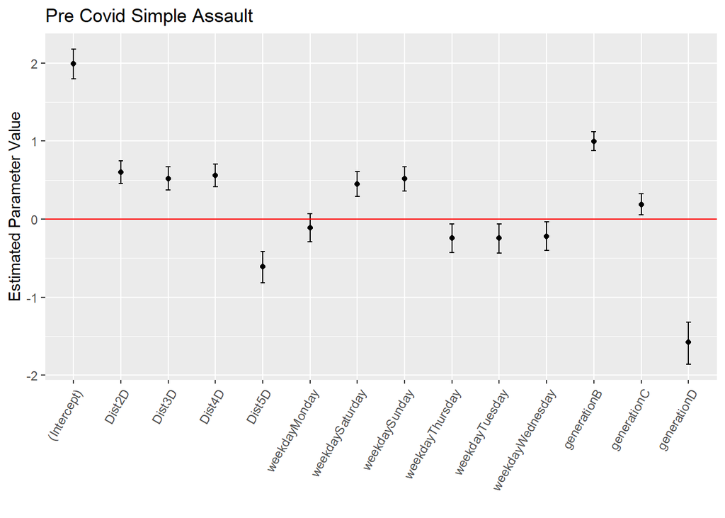

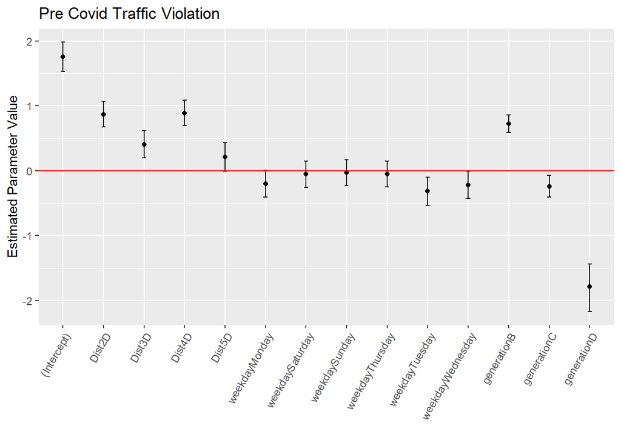

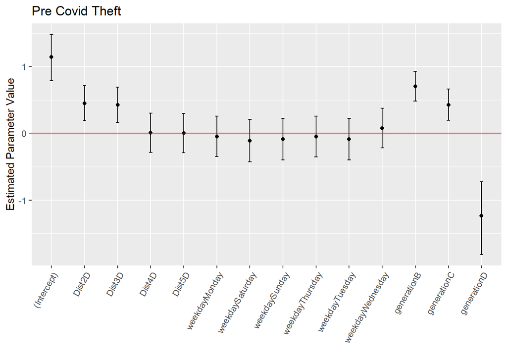

Post-Covid

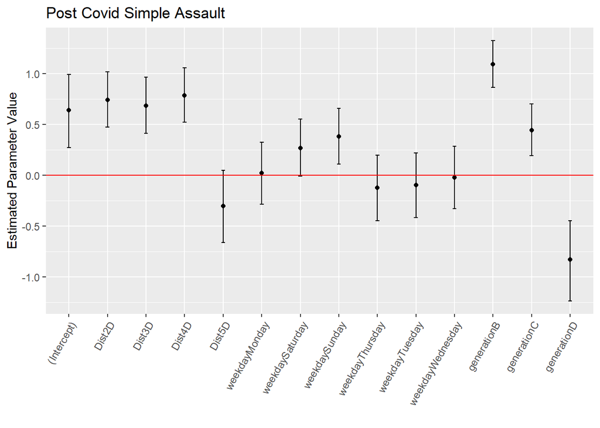

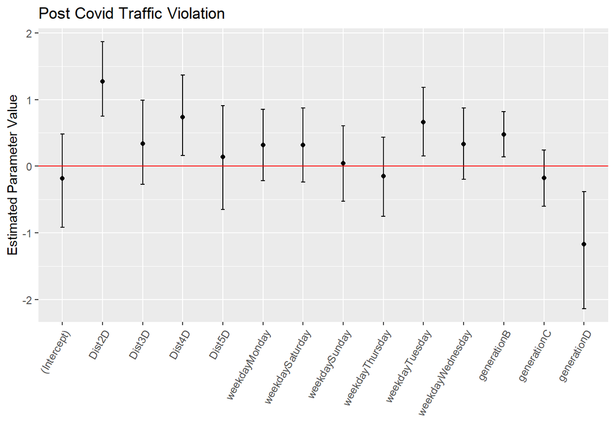

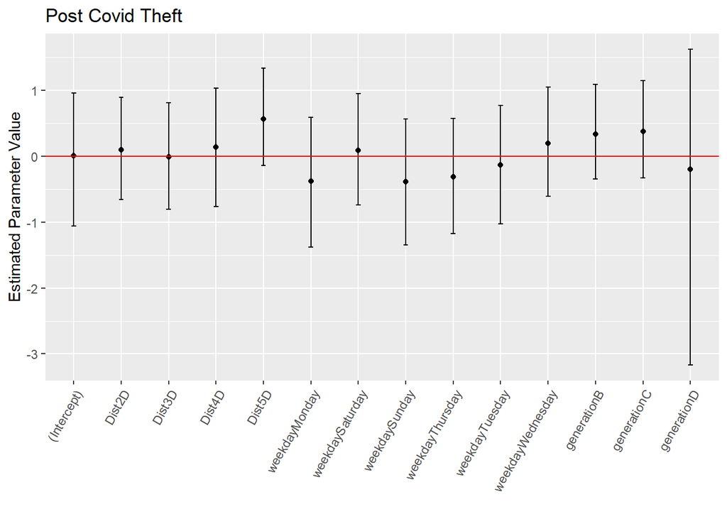